# Project: Automobile Data Analysis and Modeling (Part 1)

# Part 1: Data Preparation and Cleaning

## Data Analysis

### Data Acquisition

**Working with the Automobile Dataset**

A dataset is typically a file containing organized data, stored in one of several common formats, such as `.csv`, `.json`, or `.xlsx`. Datasets can be located in various places, including your local machine, a server, a website, or cloud storage.

To analyze a dataset in a Python notebook, we first need to load the dataset into the notebook.

For this example, we'll use the **Automobile Dataset**, which is publicly available online in CSV (Comma-Separated Values) format.

- **Data Source**: https://archive.ics.uci.edu/ml/machine-learning-databases/autos/imports-85.data
- **Data Type**: CSV

To work with this dataset, we’ll use the Pandas library. Pandas is a popular Python library for data analysis that makes it easy to read datasets and manipulate them in a structured format known as a DataFrame. Since Pandas is pre-installed in most Jupyter notebook platforms, we only need to import it to start using its features.

By combining the power of Pandas with Python, we can effectively analyze and explore this dataset in a structured and efficient way.

```python
# Define required imports
import pandas as pd
pd.options.mode.copy_on_write = True

import numpy as np
import matplotlib.pyplot as plt
import seaborn as sns
%matplotlib inline
```

### Read Data

We use the `pandas.read_csv()` function for reading CSV files.

```python
# Read Data
url = "https://archive.ics.uci.edu/ml/machine-learning-databases/autos/imports-85.data"
df = pd.read_csv(url, header=None)
```

```python
print("The last 10 rows of the dataframe\n")
df.tail(10)
```

```
The last 10 rows of the dataframe
```

|  | 0 | 1 | 2 | 3 | 4 | 5 | 6 | 7 | 8 | 9 | ... | 16 | 17 | 18 | 19 | 20 | 21 | 22 | 23 | 24 | 25 |
| --- | --- | --- | --- | --- | --- | --- | --- | --- | --- | --- | --- | --- | --- | --- | --- | --- | --- | --- | --- | --- | --- |
| 195 | -1 | 74 | volvo | gas | std | four | wagon | rwd | front | 104.3 | ... | 141 | mpfi | 3.78 | 3.15 | 9.5 | 114 | 5400 | 23 | 28 | 13415 |
| 196 | -2 | 103 | volvo | gas | std | four | sedan | rwd | front | 104.3 | ... | 141 | mpfi | 3.78 | 3.15 | 9.5 | 114 | 5400 | 24 | 28 | 15985 |
| 197 | -1 | 74 | volvo | gas | std | four | wagon | rwd | front | 104.3 | ... | 141 | mpfi | 3.78 | 3.15 | 9.5 | 114 | 5400 | 24 | 28 | 16515 |
| 198 | -2 | 103 | volvo | gas | turbo | four | sedan | rwd | front | 104.3 | ... | 130 | mpfi | 3.62 | 3.15 | 7.5 | 162 | 5100 | 17 | 22 | 18420 |
| 199 | -1 | 74 | volvo | gas | turbo | four | wagon | rwd | front | 104.3 | ... | 130 | mpfi | 3.62 | 3.15 | 7.5 | 162 | 5100 | 17 | 22 | 18950 |
| 200 | -1 | 95 | volvo | gas | std | four | sedan | rwd | front | 109.1 | ... | 141 | mpfi | 3.78 | 3.15 | 9.5 | 114 | 5400 | 23 | 28 | 16845 |
| 201 | -1 | 95 | volvo | gas | turbo | four | sedan | rwd | front | 109.1 | ... | 141 | mpfi | 3.78 | 3.15 | 8.7 | 160 | 5300 | 19 | 25 | 19045 |
| 202 | -1 | 95 | volvo | gas | std | four | sedan | rwd | front | 109.1 | ... | 173 | mpfi | 3.58 | 2.87 | 8.8 | 134 | 5500 | 18 | 23 | 21485 |
| 203 | -1 | 95 | volvo | diesel | turbo | four | sedan | rwd | front | 109.1 | ... | 145 | idi | 3.01 | 3.40 | 23.0 | 106 | 4800 | 26 | 27 | 22470 |
| 204 | -1 | 95 | volvo | gas | turbo | four | sedan | rwd | front | 109.1 | ... | 141 | mpfi | 3.78 | 3.15 | 9.5 | 114 | 5400 | 19 | 25 | 22625 |

10 rows × 26 columns

### Add Headers

Take a look at the dataset. By default, Pandas automatically assigns headers as integers starting from 0.

To make the dataset more descriptive, you can manually introduce meaningful headers. The necessary information about the dataset can be found here: [Automobile Dataset.](https://archive.ics.uci.edu/ml/datasets/Automobile.)

To add headers manually:

1. Create a list named `headers` that includes all the column names in the correct order.
2. Use `dataframe.columns = headers` to replace the default headers with the ones from your list.

```python
# Add Headers
# Create headers list
headers = ["symboling","normalized-losses","make","fuel-type","aspiration", "num-of-doors","body-style",
         "drive-wheels","engine-location","wheel-base", "length","width","height","curb-weight","engine-type",
         "num-of-cylinders", "engine-size","fuel-system","bore","stroke","compression-ratio","horsepower",
         "peak-rpm","city-mpg","highway-mpg","price"]
print("headers\n", headers)
```

[output not shown]

```python
# Replace headers and check the data
df.columns = headers
df.columns
```

```
Index(['symboling', 'normalized-losses', 'make', 'fuel-type', 'aspiration',
       'num-of-doors', 'body-style', 'drive-wheels', 'engine-location',
       'wheel-base', 'length', 'width', 'height', 'curb-weight', 'engine-type',
       'num-of-cylinders', 'engine-size', 'fuel-system', 'bore', 'stroke',
       'compression-ratio', 'horsepower', 'peak-rpm', 'city-mpg',
       'highway-mpg', 'price'],
      dtype='object')
```

```python
df.head(5)
```

|  | symboling | normalized-losses | make | fuel-type | aspiration | num-of-doors | body-style | drive-wheels | engine-location | wheel-base | ... | engine-size | fuel-system | bore | stroke | compression-ratio | horsepower | peak-rpm | city-mpg | highway-mpg | price |
| --- | --- | --- | --- | --- | --- | --- | --- | --- | --- | --- | --- | --- | --- | --- | --- | --- | --- | --- | --- | --- | --- |
| 0 | 3 | ? | alfa-romero | gas | std | two | convertible | rwd | front | 88.6 | ... | 130 | mpfi | 3.47 | 2.68 | 9.0 | 111 | 5000 | 21 | 27 | 13495 |
| 1 | 3 | ? | alfa-romero | gas | std | two | convertible | rwd | front | 88.6 | ... | 130 | mpfi | 3.47 | 2.68 | 9.0 | 111 | 5000 | 21 | 27 | 16500 |
| 2 | 1 | ? | alfa-romero | gas | std | two | hatchback | rwd | front | 94.5 | ... | 152 | mpfi | 2.68 | 3.47 | 9.0 | 154 | 5000 | 19 | 26 | 16500 |
| 3 | 2 | 164 | audi | gas | std | four | sedan | fwd | front | 99.8 | ... | 109 | mpfi | 3.19 | 3.40 | 10.0 | 102 | 5500 | 24 | 30 | 13950 |
| 4 | 2 | 164 | audi | gas | std | four | sedan | 4wd | front | 99.4 | ... | 136 | mpfi | 3.19 | 3.40 | 8.0 | 115 | 5500 | 18 | 22 | 17450 |

5 rows × 26 columns

As you can see, there are "?" symbols in the dataset. Let's replace them with `NaN` to handle missing values effectively.

```python
# Now, we need to replace the "?" symbol with NaN so the dropna() can remove the missing values:
df = df.replace("?", np.nan)
```

### Save Dataset

Correspondingly, **Pandas** enables you to save a dataset to a CSV file. Using the `dataframe.to_csv()` method, you can specify the file path and name within quotation marks inside the parentheses.

For example, if you want to save the DataFrame `df` as a file named `automobile.csv` to your local machine, you can use the syntax below. Setting `index=False` ensures that row names (index) are not included in the saved file:

```python
# Save dataset
df.to_csv("automobile.csv", index=False)
```

## Data Preprocessing

### Evaluating for Missing Data

Missing values are handled by default. To identify missing values in your dataset, you can use the following functions:

- `isnull()`: Detects missing values.
- `notnull()`: Detects non-missing values.

Both functions return a boolean value (`True` or `False`) for each element in the dataset, indicating whether the value is missing (`True` for missing data in `isnull()` and `False` for `notnull()`).

```python
df.columns
```

```
Index(['symboling', 'normalized-losses', 'make', 'fuel-type', 'aspiration',
       'num-of-doors', 'body-style', 'drive-wheels', 'engine-location',
       'wheel-base', 'length', 'width', 'height', 'curb-weight', 'engine-type',
       'num-of-cylinders', 'engine-size', 'fuel-system', 'bore', 'stroke',
       'compression-ratio', 'horsepower', 'peak-rpm', 'city-mpg',
       'highway-mpg', 'price'],
      dtype='object')
```

```python
# Evaluating for Missing Data
missing_data = df.isnull()
missing_data.head(5)
```

|  | symboling | normalized-losses | make | fuel-type | aspiration | num-of-doors | body-style | drive-wheels | engine-location | wheel-base | ... | engine-size | fuel-system | bore | stroke | compression-ratio | horsepower | peak-rpm | city-mpg | highway-mpg | price |
| --- | --- | --- | --- | --- | --- | --- | --- | --- | --- | --- | --- | --- | --- | --- | --- | --- | --- | --- | --- | --- | --- |
| 0 | False | True | False | False | False | False | False | False | False | False | ... | False | False | False | False | False | False | False | False | False | False |
| 1 | False | True | False | False | False | False | False | False | False | False | ... | False | False | False | False | False | False | False | False | False | False |
| 2 | False | True | False | False | False | False | False | False | False | False | ... | False | False | False | False | False | False | False | False | False | False |
| 3 | False | False | False | False | False | False | False | False | False | False | ... | False | False | False | False | False | False | False | False | False | False |
| 4 | False | False | False | False | False | False | False | False | False | False | ... | False | False | False | False | False | False | False | False | False | False |

5 rows × 26 columns

### Count Missing Values in Each Column

The following code iterates through each column in a DataFrame (`df`) to identify and count the missing values. For columns with missing data, it prints the column name along with the count of missing values. This is useful for quickly summarizing which parts of the dataset require attention for cleaning.

```python
# Count and print column names with missing values and their counts
for column in df.columns:
    missing_count = df[column].isnull().sum()
    if missing_count > 0:
        print(f"Column: {column}, Missing Values: {missing_count}")
```

```
Column: normalized-losses, Missing Values: 41
Column: num-of-doors, Missing Values: 2
Column: bore, Missing Values: 4
Column: stroke, Missing Values: 4
Column: horsepower, Missing Values: 2
Column: peak-rpm, Missing Values: 2
Column: price, Missing Values: 4
```

### Deal with Missing Data

**How Should You Deal with Missing Data?**

When dealing with missing data, you have two primary approaches: dropping the data or replacing the missing values with appropriate substitutes. Here is how to handle these scenarios effectively:

1. **Drop Data**
   - **Drop the Whole Row**: Remove rows containing missing values if the data is not critical for analysis or modeling.
   - **Drop the Whole Column**: Remove entire columns if the majority of entries in the column are empty.

     Note: Only drop columns when most entries are missing. In this dataset, none of the columns are empty enough to justify removing them entirely.
2. **Replace Data** Replace missing values with substitutes based on the context and the data's characteristics. Common methods include:
   - **Replace with Mean**: Suitable for numerical data when the missing values are distributed randomly.
   - **Replace with Frequency**: Best for categorical data by substituting the most frequent value.
   - **Replace Based on Other Functions**: Use a predictive model or logical assumption to infer missing values.

**Application to the Dataset**

1. **Replace by Mean**: For numerical columns, replace missing values with the mean of the column:
   - `"normalized-losses"`: 41 missing values $\rightarrow$ Replace with the column mean.
   - `"stroke"`: 4 missing values $\rightarrow$ Replace with the column mean.
   - `"bore"`: 4 missing values $\rightarrow$ Replace with the column mean.
   - `"horsepower"`: 2 missing values $\rightarrow$ Replace with the column mean.
   - `"peak-rpm"`: 2 missing values $\rightarrow$ Replace with the column mean.
2. **Replace by Frequency** For categorical columns, replace missing values with the most frequent value:
   - `"num-of-doors"`: 2 missing values $\rightarrow$ Replace with `"four"`. Because 84% of sedans in the dataset have four doors, making it the most frequent and likely value.
3. **Drop the Whole Row** Remove rows where critical data is missing:
   - `"price"`: 4 missing values $\rightarrow$ Delete the entire row. Since the target variable (`price`) is missing, these rows cannot contribute to predictive modeling. Such rows are not useful and can be safely removed.

```python
# Calculate the mean value for the "normalized-losses" column
avg_norm_loss = df["normalized-losses"].astype("float").mean(axis=0)
print("Average of normalized-losses:", avg_norm_loss)
```

```
Average of normalized-losses: 122.0
```

```python
df["normalized-losses"] = df["normalized-losses"].replace(np.nan, avg_norm_loss)
```

```python
# Calculate the mean value for the "bore" column
avg_bore=df['bore'].astype('float').mean(axis=0)
print("Average of bore:", avg_bore)

# Replace "NaN" with the mean value in the "bore" column
df['bore'] = df['bore'].replace(np.nan, avg_bore)
```

```
Average of bore: 3.3297512437810943
```

```python
# Calculate the mean value for the "horsepower" column
avg_horsepower = df['horsepower'].astype('float').mean(axis=0)
print("Average horsepower:", avg_horsepower)

# Replace "NaN" with the mean value in the "horsepower" column
df['horsepower'] = df['horsepower'].replace(np.nan, avg_horsepower)

# Calculate the mean value for "peak-rpm" column
avg_peakrpm=df['peak-rpm'].astype('float').mean(axis=0)
print("Average peak rpm:", avg_peakrpm)

# Replace "NaN" with the mean value in the "peak-rpm" column
df['peak-rpm'] = df['peak-rpm'].replace(np.nan, avg_peakrpm)

# Calculate the mean value for "peak-rpm" column
avg_pstroke=df['stroke'].astype('float').mean(axis=0)
print("Average stroke:", avg_pstroke)

# Replace "NaN" with the mean value in the "peak-rpm" column
df['stroke'] = df['stroke'].replace(np.nan, avg_pstroke)
```

```
Average horsepower: 104.25615763546799
Average peak rpm: 5125.369458128079
Average stroke: 3.255422885572139
```

```python
#replace the missing 'num-of-doors' values by the most frequent
df["num-of-doors"] = df["num-of-doors"].replace(np.nan, "four")
```

```python
#You can drop missing values along the column "price" as follows:
df = df.dropna(subset=["price"], axis=0)
df.head(5)

# reset index, because we droped "price" row
df.reset_index(drop=True, inplace=True)
```

```python
df.head(10)
```

|  | symboling | normalized-losses | make | fuel-type | aspiration | num-of-doors | body-style | drive-wheels | engine-location | wheel-base | ... | engine-size | fuel-system | bore | stroke | compression-ratio | horsepower | peak-rpm | city-mpg | highway-mpg | price |
| --- | --- | --- | --- | --- | --- | --- | --- | --- | --- | --- | --- | --- | --- | --- | --- | --- | --- | --- | --- | --- | --- |
| 0 | 3 | 122.0 | alfa-romero | gas | std | two | convertible | rwd | front | 88.6 | ... | 130 | mpfi | 3.47 | 2.68 | 9.0 | 111 | 5000 | 21 | 27 | 13495 |
| 1 | 3 | 122.0 | alfa-romero | gas | std | two | convertible | rwd | front | 88.6 | ... | 130 | mpfi | 3.47 | 2.68 | 9.0 | 111 | 5000 | 21 | 27 | 16500 |
| 2 | 1 | 122.0 | alfa-romero | gas | std | two | hatchback | rwd | front | 94.5 | ... | 152 | mpfi | 2.68 | 3.47 | 9.0 | 154 | 5000 | 19 | 26 | 16500 |
| 3 | 2 | 164 | audi | gas | std | four | sedan | fwd | front | 99.8 | ... | 109 | mpfi | 3.19 | 3.40 | 10.0 | 102 | 5500 | 24 | 30 | 13950 |
| 4 | 2 | 164 | audi | gas | std | four | sedan | 4wd | front | 99.4 | ... | 136 | mpfi | 3.19 | 3.40 | 8.0 | 115 | 5500 | 18 | 22 | 17450 |
| 5 | 2 | 122.0 | audi | gas | std | two | sedan | fwd | front | 99.8 | ... | 136 | mpfi | 3.19 | 3.40 | 8.5 | 110 | 5500 | 19 | 25 | 15250 |
| 6 | 1 | 158 | audi | gas | std | four | sedan | fwd | front | 105.8 | ... | 136 | mpfi | 3.19 | 3.40 | 8.5 | 110 | 5500 | 19 | 25 | 17710 |
| 7 | 1 | 122.0 | audi | gas | std | four | wagon | fwd | front | 105.8 | ... | 136 | mpfi | 3.19 | 3.40 | 8.5 | 110 | 5500 | 19 | 25 | 18920 |
| 8 | 1 | 158 | audi | gas | turbo | four | sedan | fwd | front | 105.8 | ... | 131 | mpfi | 3.13 | 3.40 | 8.3 | 140 | 5500 | 17 | 20 | 23875 |
| 9 | 2 | 192 | bmw | gas | std | two | sedan | rwd | front | 101.2 | ... | 108 | mpfi | 3.50 | 2.80 | 8.8 | 101 | 5800 | 23 | 29 | 16430 |

10 rows × 26 columns

### Data Standardization

Data collected from different agencies often comes in various formats. Standardization helps unify this data, enabling meaningful comparisons across datasets.

Note: The term "data standardization" can also refer to a specific type of data normalization, where you subtract the mean and divide by the standard deviation.

**What is Standardization?**

Standardization is the process of transforming data into a consistent format, allowing researchers and analysts to make meaningful comparisons.

**Example: Transforming `mpg` to `L/100km`**

In your dataset, fuel consumption is recorded in columns like `city-mpg` and `highway-mpg`, using the unit "miles per gallon" (mpg). However, you might need to adapt this data to meet standards in countries that use "liters per 100 kilometers" (L/100km).

To standardize fuel consumption data, you can apply the following formula for unit conversion: $$ \text{L/100km} = \frac{235}{\text{mpg}} $$

You can do many mathematical operations directly using Pandas.

```python
# Data Standardization
# Convert mpg to L/100km by mathematical operation (235 divided by mpg)
df['city-L/100km'] = 235/df["city-mpg"]
df['highway-L/100km'] = 235/df["highway-mpg"]

# check your transformed data
df.head()
```

|  | symboling | normalized-losses | make | fuel-type | aspiration | num-of-doors | body-style | drive-wheels | engine-location | wheel-base | ... | bore | stroke | compression-ratio | horsepower | peak-rpm | city-mpg | highway-mpg | price | city-L/100km | highway-L/100km |
| --- | --- | --- | --- | --- | --- | --- | --- | --- | --- | --- | --- | --- | --- | --- | --- | --- | --- | --- | --- | --- | --- |
| 0 | 3 | 122.0 | alfa-romero | gas | std | two | convertible | rwd | front | 88.6 | ... | 3.47 | 2.68 | 9.0 | 111 | 5000 | 21 | 27 | 13495 | 11.190476 | 8.703704 |
| 1 | 3 | 122.0 | alfa-romero | gas | std | two | convertible | rwd | front | 88.6 | ... | 3.47 | 2.68 | 9.0 | 111 | 5000 | 21 | 27 | 16500 | 11.190476 | 8.703704 |
| 2 | 1 | 122.0 | alfa-romero | gas | std | two | hatchback | rwd | front | 94.5 | ... | 2.68 | 3.47 | 9.0 | 154 | 5000 | 19 | 26 | 16500 | 12.368421 | 9.038462 |
| 3 | 2 | 164 | audi | gas | std | four | sedan | fwd | front | 99.8 | ... | 3.19 | 3.40 | 10.0 | 102 | 5500 | 24 | 30 | 13950 | 9.791667 | 7.833333 |
| 4 | 2 | 164 | audi | gas | std | four | sedan | 4wd | front | 99.4 | ... | 3.19 | 3.40 | 8.0 | 115 | 5500 | 18 | 22 | 17450 | 13.055556 | 10.681818 |

5 rows × 28 columns

### Data Normalization

When we work with data, especially for machine learning or statistical analysis, some features might have very large values compared to others. To ensure that all features contribute equally, we normalize the data to fit exactly between 0 and 1. Here’s how you can do it:

1. **Simple Feature Normalization**: This method divides each value by the maximum value of the feature. It scales the values to a range of 0 to 1.

   `df["length"] = df["length"] / df["length"].max()`
2. **Min-Max Normalization**: Here, we scale the data to fit exactly between 0 and 1.

   `df["length"] = (df["length"] - df["length"].min()) / (df["length"].max() - df["length"].min())`
3. **Z-Score Normalization**: This method adjusts the values to have a mean of 0 and a standard deviation of 1.

   `df["length"] = (df["length"] - df["length"].mean()) / df["length"].std()`

```python
# Data Normalization
# replace (original value) by (original value)/(maximum value)
df['length'] = df['length']/df['length'].max()
df['width'] = df['width']/df['width'].max()
df['height'] = df['height']/df['height'].max()

# show the scaled columns
df[["length","width","height"]].head()
```

|  | length | width | height |
| --- | --- | --- | --- |
| 0 | 0.811148 | 0.890278 | 0.816054 |
| 1 | 0.811148 | 0.890278 | 0.816054 |
| 2 | 0.822681 | 0.909722 | 0.876254 |
| 3 | 0.848630 | 0.919444 | 0.908027 |
| 4 | 0.848630 | 0.922222 | 0.908027 |

### Binning

**Why Binning?**

Binning is the process of transforming continuous numerical variables into discrete categorical 'bins' for grouped analysis. This can simplify data interpretation and make it easier to compare groups.

**Example**:

Group numerical values, for example car prices as

- `goup_names = ["Low", "Medium", "High"]`
- `bins = np.linspace(min(df["price"]), max(df["price"]), 4)`
- `df["price-binned"] = pd.cut(df["price"], bins, label=group_names, include_lowest=True)`

```python
# Binning
# Convert data to correct format:
df["horsepower"]=df["horsepower"].astype(int, copy=True)
```

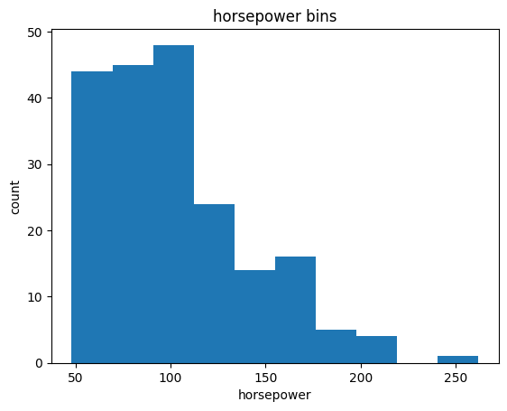

```python
# Plot the histogram of horsepower to see the distribution of horsepower.
plt.hist(df["horsepower"])

# set x/y labels and plot title
plt.xlabel("horsepower")
plt.ylabel("count")
plt.title("horsepower bins")
```

```python
# Build a bin array with a minimum value to a maximum value by using the bandwidth calculated above.
# The values will determine when one bin ends and another begins.
bins = np.linspace(min(df["horsepower"]), max(df["horsepower"]), 4)
bins
```

```
array([ 48.        , 119.33333333, 190.66666667, 262.        ])
```

```python
# Set group names
group_names = ['Low', 'Medium', 'High']

# Apply the function "cut" to determine what each value of df['horsepower'] belongs to.
df['horsepower-binned'] = pd.cut(df['horsepower'], bins, labels=group_names, include_lowest=True )
df[['horsepower','horsepower-binned']].head(20)
```

|  | horsepower | horsepower-binned |
| --- | --- | --- |
| 0 | 111 | Low |
| 1 | 111 | Low |
| 2 | 154 | Medium |
| 3 | 102 | Low |
| 4 | 115 | Low |
| 5 | 110 | Low |
| 6 | 110 | Low |
| 7 | 110 | Low |
| 8 | 140 | Medium |
| 9 | 101 | Low |
| 10 | 101 | Low |
| 11 | 121 | Medium |
| 12 | 121 | Medium |
| 13 | 121 | Medium |
| 14 | 182 | Medium |
| 15 | 182 | Medium |
| 16 | 182 | Medium |
| 17 | 48 | Low |
| 18 | 70 | Low |
| 19 | 70 | Low |

```python
# See the number of vehicles in each bin:
df["horsepower-binned"].value_counts()
```

```
horsepower-binned
Low       153
Medium     43
High        5
Name: count, dtype: int64
```

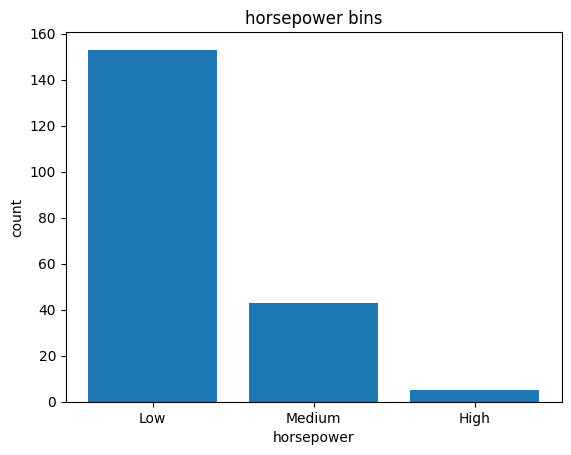

```python
# Plot the distribution of each bin:
plt.bar(group_names, df["horsepower-binned"].value_counts())

# set x/y labels and plot title
plt.xlabel("horsepower")
plt.ylabel("count")
plt.title("horsepower bins")
```

### Indicator Variable

**What is an Indicator Variable?**

An indicator variable (also called a dummy variable) is a numerical variable used to represent categories. They are referred to as "dummies" because the numbers assigned to the categories do not carry any intrinsic meaning—they merely serve as labels.

**Why Use Indicator Variables?**

Indicator variables are essential for incorporating categorical data into regression analysis. Since regression models work with numerical data, converting categorical variables into numerical representations allows them to be used in modeling and analysis.

**Example: Converting Categorical Variables to Indicator Variables**

Consider the column `"fuel-type"`, which has two unique values: `"gas"` and `"diesel"`. Regression analysis cannot directly interpret these textual values. To make them usable, you can convert `"fuel-type"` into indicator variables.

*Conversion Process*:

You can use the Pandas method `get_dummies()` to assign numerical values to different categories. For example:

- `"gas"` $\rightarrow$ `1` for `"gas"` and `0` for `"diesel"`
- `"diesel"` $\rightarrow$ `1` for `"diesel"` and `0` for `"gas"`

```python
# Indicator Variable
df.columns
```

```
Index(['symboling', 'normalized-losses', 'make', 'fuel-type', 'aspiration',
       'num-of-doors', 'body-style', 'drive-wheels', 'engine-location',
       'wheel-base', 'length', 'width', 'height', 'curb-weight', 'engine-type',
       'num-of-cylinders', 'engine-size', 'fuel-system', 'bore', 'stroke',
       'compression-ratio', 'horsepower', 'peak-rpm', 'city-mpg',
       'highway-mpg', 'price', 'city-L/100km', 'highway-L/100km',
       'horsepower-binned'],
      dtype='object')
```

```python
# Get the indicator variables and assign it to data frame "dummy_variable_1":
dummy_variable_1 = pd.get_dummies(df["fuel-type"], dtype=int)
dummy_variable_1.head()
```

|  | diesel | gas |
| --- | --- | --- |
| 0 | 0 | 1 |
| 1 | 0 | 1 |
| 2 | 0 | 1 |
| 3 | 0 | 1 |
| 4 | 0 | 1 |

```python
# Change the column names for clarity:
dummy_variable_1.rename(columns={'gas':'fuel-type-gas', 'diesel':'fuel-type-diesel'}, inplace=True)
dummy_variable_1.head()
```

|  | fuel-type-diesel | fuel-type-gas |
| --- | --- | --- |
| 0 | 0 | 1 |
| 1 | 0 | 1 |
| 2 | 0 | 1 |
| 3 | 0 | 1 |
| 4 | 0 | 1 |

```python
# In the data frame, column 'fuel-type' now has values for 'gas' and 'diesel' as 0s and 1s.
# merge data frame "df" and "dummy_variable_1"
df = pd.concat([df, dummy_variable_1], axis=1)

# drop original column "fuel-type" from "df"
df.drop("fuel-type", axis = 1, inplace=True)
```

```python
df.head()
```

|  | symboling | normalized-losses | make | aspiration | num-of-doors | body-style | drive-wheels | engine-location | wheel-base | length | ... | horsepower | peak-rpm | city-mpg | highway-mpg | price | city-L/100km | highway-L/100km | horsepower-binned | fuel-type-diesel | fuel-type-gas |
| --- | --- | --- | --- | --- | --- | --- | --- | --- | --- | --- | --- | --- | --- | --- | --- | --- | --- | --- | --- | --- | --- |
| 0 | 3 | 122.0 | alfa-romero | std | two | convertible | rwd | front | 88.6 | 0.811148 | ... | 111 | 5000 | 21 | 27 | 13495 | 11.190476 | 8.703704 | Low | 0 | 1 |
| 1 | 3 | 122.0 | alfa-romero | std | two | convertible | rwd | front | 88.6 | 0.811148 | ... | 111 | 5000 | 21 | 27 | 16500 | 11.190476 | 8.703704 | Low | 0 | 1 |
| 2 | 1 | 122.0 | alfa-romero | std | two | hatchback | rwd | front | 94.5 | 0.822681 | ... | 154 | 5000 | 19 | 26 | 16500 | 12.368421 | 9.038462 | Medium | 0 | 1 |
| 3 | 2 | 164 | audi | std | four | sedan | fwd | front | 99.8 | 0.848630 | ... | 102 | 5500 | 24 | 30 | 13950 | 9.791667 | 7.833333 | Low | 0 | 1 |
| 4 | 2 | 164 | audi | std | four | sedan | 4wd | front | 99.4 | 0.848630 | ... | 115 | 5500 | 18 | 22 | 17450 | 13.055556 | 10.681818 | Low | 0 | 1 |

5 rows × 30 columns

```python
# get indicator variables of aspiration and assign it to data frame "dummy_variable_2"
dummy_variable_2 = pd.get_dummies(df['aspiration'], dtype="int")

# change column names for clarity
dummy_variable_2.rename(columns={'std':'aspiration-std', 'turbo': 'aspiration-turbo'}, inplace=True)

# show first 5 instances of data frame "dummy_variable_1"
dummy_variable_2.head()
```

|  | aspiration-std | aspiration-turbo |
| --- | --- | --- |
| 0 | 1 | 0 |
| 1 | 1 | 0 |
| 2 | 1 | 0 |
| 3 | 1 | 0 |
| 4 | 1 | 0 |

```python
# merge the new dataframe to the original datafram
df = pd.concat([df, dummy_variable_2], axis=1)

# drop original column "aspiration" from "df"
df.drop('aspiration', axis = 1, inplace=True)
```

### Save Cleaned Data

```python
df.to_csv('clean_df.csv')
```